# MSEIRV Model (Multi-Node) Analysis

### Install the required packages

### Load the required packages

### Helper Functions

The following function `file_reader` takes as arguments the vaccine coverage in Hanoi `vCenter`, the vaccine coverage in the satellite provinces `vSatellite`, the additional doses `add_dose` (the form of this is determined by `dose_form`), the percentage allocated to Hanoi `alpha`, the distribution policy `dPolicy` and the seed_province `seed_province` and returns raw simulation output.

```r
file_reader <- function(vCenter, vSatellite, add_dose, alpha, dPolicy, seed_province) {
  name1 <- paste0(paste0("sim", paste0("_C", vCenter*100)), paste0("_O", vSatellite*100))
  name2 <- paste0(paste0(paste0("_D", add_dose/10^5), paste0("_A", alpha*100)), paste0("_P", dPolicy))
  name <- paste0(paste0(name1, name2), paste0("_", seed_province))
  dir <- paste0(paste0("sims/", seed_province), paste0(paste0("/C", vCenter*100), paste0("_O", vSatellite*100)))
  sim <- readRDS(file=paste0(paste0(dir, "/"), name))
  return(sim)
}
```

The following function `stochastic_file_reader` is a stochastic version of `file_reader`:

```r
stochastic_file_reader <- function(vCenter, vSatellite, add_dose, alpha, dPolicy, sim_num, seed_province) {
  name1 <- paste0(paste0("sim", paste0("_C", vCenter*100)), paste0("_O", vSatellite*100))
  name2 <- paste0(paste0(paste0(paste0("_D", add_dose/10^5), paste0("_A", alpha*100)), paste0("_P", dPolicy)),
                  paste0("_sim", sim_num))
  name <- paste0(paste0(name1, name2), paste0("_", seed_province))
  dir <- paste0(paste0("sims/Stochastic/", seed_province), paste0(paste0("/C", vCenter*100), paste0("_O", vSatellite*100)))
  sim <- readRDS(file=paste0(paste0(dir, "/"), name))
  return(sim)
}
```

The following function `gen_sum_stats` computes some summary statistics for a single simulation `sim`

```r
gen_sum_stats <- function(sim, vCenter, vSatellite, seed_province) {
  # read in parameter data
  dem_list <- readRDS("Parameterization/dem_list")
  disease_list <- readRDS("Parameterization/disease_list")
  stages <- nrow(dem_list$age_buckets)
  classes <- 6
  regions <- ncol(disease_list$v)

  # This function retrieves the columns of time series for a particular disease class
  get_class <- function(time.series, class_number) {
    tmp <- time.series[, -1]
    return(tmp[, (stages*(class_number - 1)+1):(stages*class_number)])
  }

  # Organize data
  time <- sim[[1]][, 1]/(365/7)
  M <- do.call(cbind, purrr::map(sim, function(x) rowSums(get_class(x, 1))))
  S <- do.call(cbind, purrr::map(sim, function(x) rowSums(get_class(x, 2))))
  E <- do.call(cbind, purrr::map(sim, function(x) rowSums(get_class(x, 3))))
  I <- do.call(cbind, purrr::map(sim, function(x) rowSums(get_class(x, 4))))
  R <- do.call(cbind, purrr::map(sim, function(x) rowSums(get_class(x, 5))))
  V <- do.call(cbind, purrr::map(sim, function(x) rowSums(get_class(x, 6))))

  # total infections
  tot_inf <- unique(max(sum(R[nrow(R), ])))

  # peak number of infectives
  peak_inf <- unique(max(rowSums(I)))

  # time of peak number of infectives
  peak_time <- unique(min(time[which(rowSums(I)==peak_inf)]))

  # number of cases averted
  #folder <- paste0(paste0(paste0(paste0(paste0(paste0(paste0("sims/", seed_province), "/"), "C"), vCenter*100), "_O"), vSatellite*100), "/")
  #name1 <- paste0(paste0("sim", paste0("_C", vCenter*100)), paste0("_O", vSatellite*100))
  #name2 <- paste0(paste0(paste0("_D", 0), paste0("_A", 0)), paste0("_P", 1))
  #file <- paste0(paste0(name1, name2), paste0("_", seed_province))
  #sim_base <- readRDS(paste0(folder, file))
  #R <- do.call(cbind, purrr::map(sim_base, function(x) rowSums(get_class(x, 5))))
  #tot_inf_base <- max(sum(R[nrow(R), ]))
  #cases_averted <- tot_inf_base - tot_inf

  # return summary stats
  df <- data.frame(tot_inf=tot_inf, peak_inf=peak_inf, peak_time=peak_time)
  return(df)
}
```

### Main Visualizations

The following function `tot_inf_main_plot` plots the cumulative infection dynamics.

```r
tot_inf_main_plot <- function(sum_stats_df, seed_province, stochastic=FALSE) {
  # take the average if stochastic
  if (stochastic) {
    sum_stats_df <- sum_stats_df %>%
      group_by(vCenter, vSatellite, add_dose, alpha) %>%
      summarize(mean_tot_inf=quantile(tot_inf, 0.5), mean_peak_inf=quantile(peak_inf, 0.5), mean_peak_time=quantile(peak_time, 0.5),
                low_tot_inf=quantile(tot_inf, 0.10), low_peak_inf=quantile(tot_inf, 0.25),
                low_peak_time=quantile(tot_inf, 0.25), high_tot_inf=quantile(tot_inf, 0.90),
                high_peak_inf=quantile(tot_inf, 0.75), high_peak_time=quantile(tot_inf, 0.75))
  }

  # equitable allocation to center provinces
  disease_list <- readRDS("Parameterization/disease_list")
  c_provinces <- c("Hà Nội", "Bắc Ninh", "Thái Nguyên", "Bắc Giang", "Vĩnh Phúc")
  total_pop <- sum(disease_list$province_data$n)
  c_total_pop <- sum(filter(disease_list$province_data, province %in% c_provinces)$n)
  equal_c_alloc <- round(c_total_pop/total_pop, 1)
  tmp_sum_stats <- sum_stats_df %>%
    mutate(alpha=(alpha - equal_c_alloc)/equal_c_alloc*100)

  tmp <- tmp_sum_stats %>%
    filter(alpha==0) %>%
    select(vCenter, vSatellite, add_dose, mean_tot_inf) %>%
    mutate(equi_tot_inf=mean_tot_inf) %>%
    select(-mean_tot_inf)
  tmp_sum_stats <- tmp_sum_stats %>%
    left_join(tmp, by=c("vCenter", "vSatellite", "add_dose")) %>%
    mutate(adj_mean_tot_inf = (mean_tot_inf-equi_tot_inf)/equi_tot_inf,
           adj_low_tot_inf = (low_tot_inf-equi_tot_inf)/equi_tot_inf,
           adj_high_tot_inf = (high_tot_inf-equi_tot_inf)/equi_tot_inf)

  getPalette = colorRampPalette(brewer.pal(9, "RdYlGn"))

  # the total number of infections over alpha: 50
  tmp_sum_stats_50 <- tmp_sum_stats %>%
    filter(vSatellite==0.5) %>%
    mutate(add_dose=as.factor(add_dose/1000000))

  tot_inf_plot_50 <- tmp_sum_stats_50 %>%
    ggplot(aes(x=alpha, y=adj_mean_tot_inf*100, group=add_dose, color=add_dose)) + geom_line() +
    geom_errorbar(aes(ymin=adj_low_tot_inf*100, ymax=adj_high_tot_inf*100), width=.2, position=position_dodge(0.05)) +
    ylim(-100, 100) +
    scale_color_manual(values = getPalette(6)) +
    labs(x = "allocation to center", y = "cumulative cases", color="\u03A9 (millions)",
         title=expression("\U003BC"[L]~"= 50%")) +
    theme(legend.position="bottom", legend.justification = "center", plot.title=element_text(hjust = 0.75, size=14),
          legend.title = element_text(size=14), legend.text = element_text(size=12)) +
    theme(axis.title.x=element_blank(), axis.title.y = element_blank(),
          panel.background = element_rect(fill = "white"), axis.line = element_line(colour = "black")) +
    geom_hline(yintercept=0) +
    guides(col = guide_legend(nrow=1, title.vjust = 0.1, title.hjust = 0.5, title.position = "bottom",
                              override.aes = list(size = 3)))
    legend <- get_legend(tot_inf_plot_50)
    title_50 <- get_title(tot_inf_plot_50)
    tot_inf_plot_50 <- tot_inf_plot_50 + theme(legend.position="none") + labs(title=NULL)

    # the total number of infections over alpha: 50
    tmp_sum_stats_60 <- tmp_sum_stats %>%
      filter(vSatellite==0.6) %>%
      mutate(add_dose=as.factor(add_dose))

    tot_inf_plot_60 <- tmp_sum_stats_60 %>%
      ggplot(aes(x=alpha, y=adj_mean_tot_inf*100, group=add_dose, color=add_dose)) + geom_line() + ylim(-100, 100) +
      geom_errorbar(aes(ymin=adj_low_tot_inf*100, ymax=adj_high_tot_inf*100), width=.2, position=position_dodge(0.05)) +
      scale_color_manual(values = getPalette(6)) +
      labs(x = "allocation to center", y = "cumulative cases", color="number of doses",
           title=expression("\U003BC"[L]~"= 60%")) +
      theme(legend.position="bottom", legend.justification = "center", plot.title=element_text(hjust = 0.70, size=14)) +
      theme(axis.title.x=element_blank(), axis.title.y=element_blank(),
            panel.background = element_rect(fill = "white"), axis.line = element_line(colour = "black")) +
      geom_hline(yintercept=0)
    title_60 <- get_title(tot_inf_plot_60)
    tot_inf_plot_60 <- tot_inf_plot_60 + theme(legend.position="none") + labs(title=NULL)

    # the total number of infections over alpha: 50
    tmp_sum_stats_70 <- tmp_sum_stats %>%
      filter(vSatellite==0.7) %>%
      mutate(add_dose=as.factor(add_dose))

    tot_inf_plot_70 <- tmp_sum_stats_70 %>%
      ggplot(aes(x=alpha, y=adj_mean_tot_inf*100, group=add_dose, color=add_dose)) + geom_line() + ylim(-500, 500) +
      geom_errorbar(aes(ymin=adj_low_tot_inf*100, ymax=adj_high_tot_inf*100), width=.2, position=position_dodge(0.05)) +
      scale_color_manual(values = getPalette(6)) +
      labs(x = "allocation to center", y = "cumulative cases", color="number of doses",
           title=expression("\U003BC"[L]~"= 70%")) +
      theme(legend.position="bottom", legend.justification = "center", plot.title=element_text(hjust = 0.65, size=14)) +
      theme(axis.title.x=element_blank(), axis.title.y=element_blank(),
            panel.background = element_rect(fill = "white"), axis.line = element_line(colour = "black")) +
      geom_hline(yintercept=0)
    title_70 <- get_title(tot_inf_plot_70)
    tot_inf_plot_70 <- tot_inf_plot_70 + theme(legend.position="none") + labs(title=NULL)

    # the total number of infections over alpha: 50
    tmp_sum_stats_80 <- tmp_sum_stats %>%
      filter(vSatellite==0.8) %>%
      mutate(add_dose=as.factor(add_dose))

    tot_inf_plot_80 <- tmp_sum_stats_80 %>%
      ggplot(aes(x=alpha, y=adj_mean_tot_inf*100, group=add_dose, color=add_dose)) + geom_line() + ylim(-100, 100) +
      geom_errorbar(aes(ymin=adj_low_tot_inf*100, ymax=adj_high_tot_inf*100), width=.2, position=position_dodge(0.05)) +
      scale_color_manual(values = getPalette(6)) +
      labs(x = "allocation to center", y = "cumulative cases", color="number of doses",
           title=expression("\U003BC"[L]~"= 80%")) +
      theme(legend.position="bottom", legend.justification = "center", plot.title=element_text(hjust = 0.6, size=14)) +
      theme(axis.title.x=element_blank(), axis.title.y=element_blank(),
            panel.background = element_rect(fill = "white"), axis.line = element_line(colour = "black")) +
      geom_hline(yintercept=0)
    title_80 <- get_title(tot_inf_plot_80)
    tot_inf_plot_80 <- tot_inf_plot_80 + theme(legend.position="none") + labs(title=NULL)

    ytitle <- ggdraw() +
      draw_label("change in cumulative cases relative to equitable allocation (%)", angle=90, size=14)
    xtitle <- ggdraw() +
      draw_label("deviation from equitable allocation (%)", size=14)
    pline <- plot_grid(ytitle, tot_inf_plot_50, tot_inf_plot_60, tot_inf_plot_70, tot_inf_plot_80, ncol = 5,
                       rel_widths = c(0.1, 1.1, 1, 1, 1), labels = c("", "A", "B", "C", "D"))
    titles <- plot_grid(title_50, title_60, title_70, title_80, ncol=4)
    p <- plot_grid(titles, pline, xtitle, legend, nrow=4, rel_heights = c(0.05, 1, 0.05, .2))
    print(p)
}
```

The following function `plot_inf_main_plot` takes as arguments a dataframe of summary data for the simulations `sum_stats_df`, the seed province `seed_province` and a boolean variable for whether the simulations are stochastic with multiple runs per condition, and then plots the how the peak of the epidemic changes under different conditions.

```r
peak_inf_main_plot <- function(sum_stats_df, seed_province, stochastic=FALSE) {
  # take the average if stochastic
  if (stochastic) {
    sum_stats_df <- sum_stats_df %>%
      group_by(vCenter, vSatellite, add_dose, alpha) %>%
      summarize(mean_tot_inf=mean(tot_inf), mean_peak_inf=mean(peak_inf), mean_peak_time=mean(peak_time),
                low_tot_inf=quantile(tot_inf, 0.05), low_peak_inf=quantile(peak_inf, 0.05),
                low_peak_time=quantile(peak_time, 0.05), high_tot_inf=quantile(tot_inf, 0.95),
                high_peak_inf=quantile(peak_inf, 0.95), high_peak_time=quantile(peak_time, 0.95))
  }

  # equitable allocation to center provinces
  disease_list <- readRDS("Parameterization/disease_list")
  c_provinces <- c("Hà Nội", "Bắc Ninh", "Thái Nguyên", "Bắc Giang", "Vĩnh Phúc")
  total_pop <- sum(disease_list$province_data$n)
  c_total_pop <- sum(filter(disease_list$province_data, province %in% c_provinces)$n)
  equal_c_alloc <- round(c_total_pop/total_pop, 1)
  tmp_sum_stats <- sum_stats_df %>%
    mutate(alpha=(alpha - equal_c_alloc)/equal_c_alloc*100)

  tmp <- tmp_sum_stats %>%
    filter(alpha==0) %>%
    select(vCenter, vSatellite, add_dose, mean_peak_inf) %>%
    mutate(equi_peak_inf=mean_peak_inf) %>%
    select(-mean_peak_inf)
  tmp_sum_stats <- tmp_sum_stats %>%
    left_join(tmp, by=c("vCenter", "vSatellite", "add_dose")) %>%
    mutate(adj_mean_peak_inf = (mean_peak_inf-equi_peak_inf)/equi_peak_inf,
           adj_low_peak_inf = (low_peak_inf-equi_peak_inf)/equi_peak_inf,
           adj_high_peak_inf = (high_peak_inf-equi_peak_inf)/equi_peak_inf)

  getPalette = colorRampPalette(brewer.pal(9, "RdYlGn"))

  # the total number of infections over alpha: 50
  tmp_sum_stats_50 <- tmp_sum_stats %>%
    filter(vSatellite==0.5) %>%
    mutate(add_dose=as.factor(add_dose/1000000))

  peak_inf_plot_50 <- tmp_sum_stats_50 %>%
    ggplot(aes(x=alpha, y=adj_mean_peak_inf*100, group=add_dose, color=add_dose)) + geom_line(position=position_dodge(width=30)) +
    geom_errorbar(aes(ymin=adj_low_peak_inf*100, ymax=adj_high_peak_inf*100, color=add_dose, group=add_dose),
                  width=.01, position=position_dodge(30)) +
    ylim(-100, 100) +
    scale_color_manual(values = getPalette(6)) +
    labs(x = "allocation to center", y = "cumulative cases", color="\u03A9 (millions)",
         title=expression("\U003BC"[L]~"= 50%")) +
    theme(legend.position="bottom", legend.justification = "center", plot.title=element_text(hjust = 0.75, size=14),
          legend.title = element_text(size=14), legend.text = element_text(size=12)) +
    theme(axis.title.x=element_blank(), axis.title.y = element_blank(),
          panel.background = element_rect(fill = "white"), axis.line = element_line(colour = "black")) +
    geom_hline(yintercept=0) +
    guides(col = guide_legend(nrow=1, title.vjust = 0.1, title.hjust = 0.5, title.position = "bottom",
                              override.aes = list(size = 3)))
    legend <- get_legend(peak_inf_plot_50)
    title_50 <- get_title(peak_inf_plot_50)
    peak_inf_plot_50 <- peak_inf_plot_50 + theme(legend.position="none") + labs(title=NULL)

    # the peakal number of infections over alpha: 50
    tmp_sum_stats_60 <- tmp_sum_stats %>%
      filter(vSatellite==0.6) %>%
      mutate(add_dose=as.factor(add_dose))

    peak_inf_plot_60 <- tmp_sum_stats_60 %>%
      ggplot(aes(x=alpha, y=adj_mean_peak_inf*100, group=add_dose, color=add_dose)) + geom_line() + ylim(-100, 100) +
      geom_errorbar(aes(ymin=adj_low_peak_inf*100, ymax=adj_high_peak_inf*100), width=.2, position=position_dodge(0.05)) +
      scale_color_manual(values = getPalette(6)) +
      labs(x = "allocation to center", y = "cumulative cases", color="number of doses",
           title=expression("\U003BC"[L]~"= 60%")) +
      theme(legend.position="bottom", legend.justification = "center", plot.title=element_text(hjust = 0.70, size=14)) +
      theme(axis.title.x=element_blank(), axis.title.y=element_blank(),
            panel.background = element_rect(fill = "white"), axis.line = element_line(colour = "black")) +
      geom_hline(yintercept=0)
    title_60 <- get_title(peak_inf_plot_60)
    peak_inf_plot_60 <- peak_inf_plot_60 + theme(legend.position="none") + labs(title=NULL)

    # the total number of infections over alpha: 50
    tmp_sum_stats_70 <- tmp_sum_stats %>%
      filter(vSatellite==0.7) %>%
      mutate(add_dose=as.factor(add_dose))

    peak_inf_plot_70 <- tmp_sum_stats_70 %>%
      ggplot(aes(x=alpha, y=adj_mean_peak_inf*100, group=add_dose, color=add_dose)) + geom_line() + ylim(-100, 100) +
      geom_errorbar(aes(ymin=adj_low_peak_inf*100, ymax=adj_high_peak_inf*100), width=.2, position=position_dodge(0.05)) +
      scale_color_manual(values = getPalette(6)) +
      labs(x = "allocation to center", y = "cumulative cases", color="number of doses",
           title=expression("\U003BC"[L]~"= 70%")) +
      theme(legend.position="bottom", legend.justification = "center", plot.title=element_text(hjust = 0.65, size=14)) +
      theme(axis.title.x=element_blank(), axis.title.y=element_blank(),
            panel.background = element_rect(fill = "white"), axis.line = element_line(colour = "black")) +
      geom_hline(yintercept=0)
    title_70 <- get_title(peak_inf_plot_70)
    peak_inf_plot_70 <- peak_inf_plot_70 + theme(legend.position="none") + labs(title=NULL)

    # the total number of infections over alpha: 50
    tmp_sum_stats_80 <- tmp_sum_stats %>%
      filter(vSatellite==0.8) %>%
      mutate(add_dose=as.factor(add_dose))

    peak_inf_plot_80 <- tmp_sum_stats_80 %>%
      ggplot(aes(x=alpha, y=adj_mean_peak_inf*100, group=add_dose, color=add_dose)) + geom_line() + ylim(-500, 500) +
      geom_errorbar(aes(ymin=adj_low_peak_inf*100, ymax=adj_high_peak_inf*100), width=.2, position=position_dodge(0.05)) +
      scale_color_manual(values = getPalette(6)) +
      labs(x = "allocation to center", y = "cumulative cases", color="number of doses",
           title=expression("\U003BC"[L]~"= 80%")) +
      theme(legend.position="bottom", legend.justification = "center", plot.title=element_text(hjust = 0.6, size=14)) +
      theme(axis.title.x=element_blank(), axis.title.y=element_blank(),
            panel.background = element_rect(fill = "white"), axis.line = element_line(colour = "black")) +
      geom_hline(yintercept=0)
    title_80 <- get_title(peak_inf_plot_80)
    peak_inf_plot_80 <- peak_inf_plot_80 + theme(legend.position="none") + labs(title=NULL)

    ytitle <- ggdraw() +
      draw_label("change in peak cases relative to equitable allocation (%)", angle=90, size=14)
    xtitle <- ggdraw() +
      draw_label("deviation from equitable allocation (%)", size=14)
    pline <- plot_grid(ytitle, peak_inf_plot_50, peak_inf_plot_60, peak_inf_plot_70, peak_inf_plot_80, ncol = 5,
                       rel_widths = c(0.1, 1.1, 1, 1, 1), labels = c("", "A", "B", "C", "D"))
    titles <- plot_grid(title_50, title_60, title_70, title_80, ncol=4)
    p <- plot_grid(titles, pline, xtitle, legend, nrow=4, rel_heights = c(0.05, 1, 0.05, .2))
    print(p)
}
```

The following function `peak_time_main_plot` takes as arguments a dataframe of summary data for the simulations `sum_stats_df`, the seed province `seed_province` and a boolean variable for whether the simulations are stochastic with multiple runs per condition, and then plots the how the time of the peak of the epidemic changes under different conditions.

```r
peak_time_main_plot <- function(sum_stats_df, seed_province, stochastic=FALSE) {
  # take the average if stochastic
  if (stochastic) {
    sum_stats_df <- sum_stats_df %>%
      group_by(vCenter, vSatellite, add_dose, alpha) %>%
      summarize(mean_tot_inf=mean(tot_inf), mean_peak_inf=mean(peak_inf), mean_peak_time=mean(peak_time),
                low_tot_inf=quantile(tot_inf, 0.05), low_peak_inf=quantile(peak_inf, 0.05),
                low_peak_time=quantile(peak_time, 0.05), high_tot_inf=quantile(tot_inf, 0.95),
                high_peak_inf=quantile(peak_inf, 0.95), high_peak_time=quantile(peak_time, 0.95))
  }

  # equitable allocation to center provinces
  disease_list <- readRDS("Parameterization/disease_list")
  c_provinces <- c("Hà Nội", "Bắc Ninh", "Thái Nguyên", "Bắc Giang", "Vĩnh Phúc")
  total_pop <- sum(disease_list$province_data$n)
  c_total_pop <- sum(filter(disease_list$province_data, province %in% c_provinces)$n)
  equal_c_alloc <- round(c_total_pop/total_pop, 1)
  tmp_sum_stats <- sum_stats_df %>%
    mutate(alpha=(alpha - equal_c_alloc)/equal_c_alloc*100)

  tmp <- tmp_sum_stats %>%
    filter(alpha==0) %>%
    select(vCenter, vSatellite, add_dose, mean_peak_time) %>%
    mutate(equi_peak_time=mean_peak_time) %>%
    select(-mean_peak_time)
  tmp_sum_stats <- tmp_sum_stats %>%
    left_join(tmp, by=c("vCenter", "vSatellite", "add_dose")) %>%
    mutate(adj_mean_peak_time = (mean_peak_time-equi_peak_time)/equi_peak_time,
           adj_low_peak_time = (low_peak_time-equi_peak_time)/equi_peak_time,
           adj_high_peak_time = (high_peak_time-equi_peak_time)/equi_peak_time)

  getPalette = colorRampPalette(brewer.pal(9, "RdYlGn"))

  # the total number of infections over alpha: 50
  tmp_sum_stats_50 <- tmp_sum_stats %>%
    filter(vSatellite==0.5) %>%
    mutate(add_dose=as.factor(add_dose/1000000))

  peak_time_plot_50 <- tmp_sum_stats_50 %>%
    ggplot(aes(x=alpha, y=adj_mean_peak_time*100, group=add_dose, color=add_dose)) + geom_line() +
    geom_errorbar(aes(ymin=adj_low_peak_time*100, ymax=adj_high_peak_time*100), width=.2, position=position_dodge(0.05)) +
    ylim(-100, 100) +
    scale_color_manual(values = getPalette(6)) +
    labs(x = "allocation to center", y = "cumulative cases", color="\u03A9 (millions)",
         title=expression("\U003BC"[L]~"= 50%")) +
    theme(legend.position="bottom", legend.justification = "center", plot.title=element_text(hjust = 0.75, size=14),
          legend.title = element_text(size=14), legend.text = element_text(size=12)) +
    theme(axis.title.x=element_blank(), axis.title.y = element_blank(),
          panel.background = element_rect(fill = "white"), axis.line = element_line(colour = "black")) +
    geom_hline(yintercept=0) +
    guides(col = guide_legend(nrow=1, title.vjust = 0.1, title.hjust = 0.5, title.position = "bottom",
                              override.aes = list(size = 3)))
    legend <- get_legend(peak_time_plot_50)
    title_50 <- get_title(peak_time_plot_50)
    peak_time_plot_50 <- peak_time_plot_50 + theme(legend.position="none") + labs(title=NULL)

    # the peakal number of infections over alpha: 50
    tmp_sum_stats_60 <- tmp_sum_stats %>%
      filter(vSatellite==0.6) %>%
      mutate(add_dose=as.factor(add_dose))

    peak_time_plot_60 <- tmp_sum_stats_60 %>%
      ggplot(aes(x=alpha, y=adj_mean_peak_time*100, group=add_dose, color=add_dose)) + geom_line() + ylim(-100, 100) +
      geom_errorbar(aes(ymin=adj_low_peak_time*100, ymax=adj_high_peak_time*100), width=.2, position=position_dodge(0.05)) +
      scale_color_manual(values = getPalette(6)) +
      labs(x = "allocation to center", y = "cumulative cases", color="number of doses",
           title=expression("\U003BC"[L]~"= 60%")) +
      theme(legend.position="bottom", legend.justification = "center", plot.title=element_text(hjust = 0.70, size=14)) +
      theme(axis.title.x=element_blank(), axis.title.y=element_blank(),
            panel.background = element_rect(fill = "white"), axis.line = element_line(colour = "black")) +
      geom_hline(yintercept=0)
    title_60 <- get_title(peak_time_plot_60)
    peak_time_plot_60 <- peak_time_plot_60 + theme(legend.position="none") + labs(title=NULL)

    # the total number of infections over alpha: 50
    tmp_sum_stats_70 <- tmp_sum_stats %>%
      filter(vSatellite==0.7) %>%
      mutate(add_dose=as.factor(add_dose))

    peak_time_plot_70 <- tmp_sum_stats_70 %>%
      ggplot(aes(x=alpha, y=adj_mean_peak_time*100, group=add_dose, color=add_dose)) + geom_line() + ylim(-200, 200) +
      geom_errorbar(aes(ymin=adj_low_peak_time*100, ymax=adj_high_peak_time*100), width=.2, position=position_dodge(0.05)) +
      scale_color_manual(values = getPalette(6)) +
      labs(x = "allocation to center", y = "cumulative cases", color="number of doses",
           title=expression("\U003BC"[L]~"= 70%")) +
      theme(legend.position="bottom", legend.justification = "center", plot.title=element_text(hjust = 0.65, size=14)) +
      theme(axis.title.x=element_blank(), axis.title.y=element_blank(),
            panel.background = element_rect(fill = "white"), axis.line = element_line(colour = "black")) +
      geom_hline(yintercept=0)
    title_70 <- get_title(peak_time_plot_70)
    peak_time_plot_70 <- peak_time_plot_70 + theme(legend.position="none") + labs(title=NULL)

    # the total number of infections over alpha: 50
    tmp_sum_stats_80 <- tmp_sum_stats %>%
      filter(vSatellite==0.8) %>%
      mutate(add_dose=as.factor(add_dose))

    peak_time_plot_80 <- tmp_sum_stats_80 %>%
      ggplot(aes(x=alpha, y=adj_mean_peak_time*100, group=add_dose, color=add_dose)) + geom_line() + ylim(-750, 750) +
      geom_errorbar(aes(ymin=adj_low_peak_time*100, ymax=adj_high_peak_time*100), width=.2, position=position_dodge(0.05)) +
      scale_color_manual(values = getPalette(6)) +
      labs(x = "allocation to center", y = "cumulative cases", color="number of doses",
           title=expression("\U003BC"[L]~"= 80%")) +
      theme(legend.position="bottom", legend.justification = "center", plot.title=element_text(hjust = 0.6, size=14)) +
      theme(axis.title.x=element_blank(), axis.title.y=element_blank(),
            panel.background = element_rect(fill = "white"), axis.line = element_line(colour = "black")) +
      geom_hline(yintercept=0)
    title_80 <- get_title(peak_time_plot_80)
    peak_time_plot_80 <- peak_time_plot_80 + theme(legend.position="none") + labs(title=NULL)

    ytitle <- ggdraw() +
      draw_label("change in cumulative cases relative to equitable allocation (%)", angle=90, size=14)
    xtitle <- ggdraw() +
      draw_label("deviation from equitable allocation (%)", size=14)
    pline <- plot_grid(ytitle, peak_time_plot_50, peak_time_plot_60, peak_time_plot_70, peak_time_plot_80, ncol = 5,
                       rel_widths = c(0.1, 1.1, 1, 1, 1), labels = c("", "A", "B", "C", "D"))
    titles <- plot_grid(title_50, title_60, title_70, title_80, ncol=4)
    p <- plot_grid(titles, pline, xtitle, legend, nrow=4, rel_heights = c(0.05, 1, 0.05, .2))
    print(p)
}
```

The following function `geo_cum_nums` provides an indication of the incidence of cases across Northern Vietnam.

```r
geo_case_nums <- function(sum_stats_df, seed_province, stochastic=FALSE) {
    dem_list <- readRDS("Parameterization/dem_list")
    disease_list <- readRDS("Parameterization/disease_list")

    if (stochastic) {
    sum_stats_df <- sum_stats_df %>%
      group_by(vCenter, vSatellite, add_dose, alpha) %>%
      summarize(tot_inf=mean(tot_inf), peak_inf=mean(peak_inf), peak_time=mean(peak_time))
    }

    # compute the optimal alpha over all additional doses for each satellite province vaccine coverage
    gen_opt_alpha <- function(this_vSatellite) {
      vSat_sum_stat <- filter(sum_stats_df, vSatellite==this_vSatellite)
      add_dose <- unique(pull(vSat_sum_stat, add_dose))

      # cumulative cases
      f <- function(x) {
        return(unique(x[which(x$tot_inf == min(x$tot_inf)), ]$alpha))
      }
      min_cum_cases_alpha <- unlist(purrr::map(add_dose, function(x) f(filter(vSat_sum_stat, add_dose==x))))
      df <- data.frame(add_dose=add_dose, min_cum_cases_alpha=min_cum_cases_alpha)
      return(df)
      }
    vSatellites <- unique(pull(sum_stats_df, vSatellite))
    tmp <- purrr::map(vSatellites, gen_opt_alpha)
    opt_alpha_df <- do.call(rbind,
                            purrr::map(1:length(vSatellites),
                                       function(x) cbind(vSatellite=rep(vSatellites[x], nrow(tmp[[x]])), tmp[[x]])))
    opt_alpha_df <- cbind(vCenter=rep(0.8, nrow(opt_alpha_df)), opt_alpha_df)

    # let's scale this down
    opt_alpha_df <- opt_alpha_df %>%
      filter(vSatellite %in% c(0.5, 0.6, 0.7, 0.8)) %>%
      filter(((add_dose == 10*10^5) | (add_dose == 20*10^5) | (add_dose == 30*10^5)))

    # let's generate a spatial map
    generate_spatial_map <- function(vCenter, vSatellite, add_dose, alpha) {
      sim <- file_reader(vCenter=vCenter, vSatellite=vSatellite, add_dose=add_dose, alpha=alpha, dPolicy=1, seed_province=seed_province)

      # read in parameter data
      dem_list <- readRDS("Parameterization/dem_list")
      disease_list <- readRDS("Parameterization/disease_list")
      stages <- nrow(dem_list$age_buckets)
      classes <- 6
      regions <- ncol(disease_list$v)
      get_class <- function(time.series, class_number) {
        tmp <- time.series[, -1]
        return(tmp[, (stages*(class_number - 1)+1):(stages*class_number)])
        }
      R <- do.call(cbind, purrr::map(sim, function(x) rowSums(get_class(x, 5))))

      # total infections
      tot_inf <- R[nrow(R), ]

      # range
      rng = range(c((0), (5.5)))
      colors = colorRampPalette(brewer.pal(9, "OrRd"))(3)

      # plot
      tmp <- select(disease_list$province_data, province, geometry) %>%
        cbind(tot_inf=tot_inf)
      incidence_plot <- ggplot() +
        geom_sf(data=tmp, aes(geometry=geometry, fill=as.numeric(tot_inf/10^5))) +
        scale_fill_gradient2(low=colors[1], mid=colors[2], high=colors[3], #colors in the scale
                 midpoint=mean(rng),
                 breaks = seq(0, 5), labels=seq(0, 5), limits=c(floor(rng[1]), ceiling(rng[2]))) +
        theme_bw() +
        theme(panel.grid.major = element_blank(), panel.grid.minor = element_blank(),
              panel.background = element_blank(), panel.border = element_blank(), plot.title=element_text(hjust = 0.50, size=10),
              axis.line = element_blank(), axis.ticks = element_blank(), axis.text = element_blank()) +
        labs(fill=expression("cumulative cases (100,000s)"),
             caption=substitute(paste(paste('\u03B1'['opt']~'= ', nn), "%"), list(nn=alpha*100))) +
        theme(plot.caption = element_text(hjust=0.5, size=12)) +
        theme(legend.text = element_text(size = 14), legend.title = element_text(size=14),
              legend.title.align = 0, legend.position = "bottom", legend.key.width=unit(3, "cm"),
              legend.key.height = unit(1, "cm")) +
        guides(fill = guide_colourbar(title.vjust = 0.1, title.hjust = 0.5, title.position = "bottom"))
      return(incidence_plot)
    }

    create_column_plots <- function(my_vSatellite) {
      tmp <- filter(opt_alpha_df, vSatellite==my_vSatellite)
      plot1 <- generate_spatial_map(vCenter=0.8, vSatellite=my_vSatellite, add_dose=tmp[1,3], alpha=tmp[1,4]) +
        theme(legend.position="none")
      plot2 <- generate_spatial_map(vCenter=0.8, vSatellite=my_vSatellite, add_dose=tmp[2,3], alpha=tmp[2,4]) +
        theme(legend.position="none")
      plot3 <- generate_spatial_map(vCenter=0.8, vSatellite=my_vSatellite, add_dose=tmp[3,3], alpha=tmp[3,4]) +
        theme(legend.position="none")
      return(plot_grid(plot1, plot2, plot3, ncol = 1, nrow=3))
    }

    gen_legend <- function() {
      plot1 <- generate_spatial_map(vCenter=opt_alpha_df[1, 1], vSatellite=opt_alpha_df[1, 2],
                                    add_dose=opt_alpha_df[1, 3], alpha=opt_alpha_df[1, 4])
      legend <- get_legend(plot1)
      return(legend)
    }
    all_plots <- plot_grid(create_column_plots(0.5), create_column_plots(0.6), create_column_plots(0.7), create_column_plots(0.8),
                           ncol=4)
    ylabels <- plot_grid(ggdraw() + draw_label("", angle=90, size=10),
                         ggdraw() + draw_label(paste0("\u03A9=", "1,000,000"), angle=90, size=14),
                         ggdraw() + draw_label(paste0("\u03A9=", "2,000,000"), angle=90, size=14),
                         ggdraw() + draw_label(paste0("\u03A9=", "3,000,000"), angle=90, size=14),
                         nrow=4, rel_heights=c(0.1, 1, 1, 1))
    xlabels <- plot_grid(ggdraw() + draw_label(expression("\U003BC"[L]~"= 50%"), size=14),
                         ggdraw() + draw_label(expression("\U003BC"[L]~"= 60%"), size=14),
                         ggdraw() + draw_label(expression("\U003BC"[L]~"= 70%"), size=14),
                         ggdraw() + draw_label(expression("\U003BC"[L]~"= 80%"), size=14),
                         ncol=4)
    plots <- plot_grid(plot_grid(ylabels, plot_grid(xlabels, all_plots, nrow=2, rel_heights = c(0.1, 1)),
                                 ncol=2, rel_widths = c(0.1, 1)), gen_legend(), nrow=2, rel_heights = c(1, 0.2))
    print(plots)
    return()
}
```

The following function plots the typical infection dynamics under base-line distribution:

```r
typical_inf_dynamics <- function(seed_province) {
  dem_list <- readRDS("Parameterization/dem_list")
  disease_list <- readRDS("Parameterization/disease_list")
  province_data <- readRDS("Parameterization/disease_list")$province_data
  stages <- nrow(dem_list$age_buckets)
  classes <- 6
  regions <- ncol(disease_list$v)

  gen_plot <- function(vSatellite, leg=FALSE, tot_cases=FALSE) {
    sim <- file_reader(vCenter=0.8, vSatellite=vSatellite, add_dose=0, alpha=0, dPolicy=1, seed_province="Hà Giang")

    smooth <- function(this_sim) {
      I <- c("I1", "I2", "I3", "I4", "I5", "I6", "I7", "I8", "I9")
      time_values <- data.frame(time = this_sim[, "time"])
      for (i in I) {
        y1 <- smooth.spline(x=this_sim[, "time"], y=this_sim[, i])
        tmp <- predict(y1, x=time_values)$y$time
        tmp[which(tmp < 0)] <- 0
        this_sim[, i] <- tmp
        }
      return(this_sim)
      }
    sim <- purrr::map(sim, function(x) smooth(x))
    get_class <- function(time.series, class_number) {
      tmp <- time.series[, -1]
      return(tmp[, (stages*(class_number - 1)+1):(stages*class_number)])
      }
    # Organize data
    time <- sim[[1]][, 1]/(365/7)
    I <- do.call(cbind, purrr::map(sim, function(x) rowSums(get_class(x, 4))))

    if (tot_cases==TRUE)
      return(sum(I))

    inf_plot <- setNames(data.frame(time, I), c("time", province_data$province)) %>%
      gather(key = province, value = number, 2:ncol(data.frame(time, I))) %>%
      left_join(select(province_data, province, Community)) %>%
      ggplot(aes(x = time, y = number, color = Community, group = province)) + geom_line() +
      labs(x = "time (years)", title=substitute(paste(paste("\U003BC"[L]~"= ", nn), "%"), list(nn=vSatellite*100)),
           y="cases") +
      xlim(0, 3) + ylim(0, 62000) +
      theme(legend.position="bottom", legend.justification = "center", plot.title=element_text(hjust = 0.5, size=14),
          legend.title = element_text(size=14), legend.text=element_text(size=14)) +
      theme(axis.title.x = element_blank(), axis.title.y=element_blank(), axis.text.x=element_text(size=12),
            axis.text.y=element_text(size=12),
            panel.background = element_rect(fill = "white"), axis.line = element_line(colour = "black")) +
      guides(color = guide_legend(override.aes = list(size = 2)))
    if(leg==FALSE)
      inf_plot <- inf_plot + theme(legend.position="none")
    return(inf_plot)
  }
  total_cases <- plot_grid(ggdraw() + draw_label("5,683,478", size=10),
                           ggdraw() + draw_label("3,554,197", size=10),
                           ggdraw() + draw_label("1,802,848", size=10),
                           ggdraw() + draw_label("412,387", size=10), ncol=4)
  xtitle <- ggdraw() +
      draw_label("time (years)", size=14)
  ytitle <- ggdraw() +
    draw_label("cases", size=14, angle=90)
  pline <- plot_grid(ytitle, gen_plot(0.5), gen_plot(0.6), gen_plot(0.7), gen_plot(0.8), ncol = 5,
                       rel_widths = c(0.1, 1.1, 1, 1, 1), labels = c("", "A", "B", "C", "D"))
  legend <- get_legend(gen_plot(0.5, leg=TRUE))
  p <- plot_grid(pline, xtitle, legend, nrow=3, rel_heights = c(1, 0.05, .2))
  print(p)
}
```

The following function plots the typical infection dynamics under base-line distribution acroos a spatila map of Northern Vietnam.

```r
geo_typical_inf_dynamics <- function(seed_province) {
  dem_list <- readRDS("Parameterization/dem_list")
  disease_list <- readRDS("Parameterization/disease_list")
  province_data <- readRDS("Parameterization/disease_list")$province_data
  stages <- nrow(dem_list$age_buckets)
  classes <- 6
  regions <- ncol(disease_list$v)

  gen_plot <- function(vSatellite, leg=FALSE) {
    sim <- file_reader(vCenter=0.8, vSatellite=vSatellite, add_dose=0, alpha=0, dPolicy=1, seed_province="Hà Giang")

    smooth <- function(this_sim) {
      I <- c("I1", "I2", "I3", "I4", "I5", "I6", "I7", "I8", "I9")
      time_values <- data.frame(time = this_sim[, "time"])
      for (i in I) {
        y1 <- smooth.spline(x=this_sim[, "time"], y=this_sim[, i])
        tmp <- predict(y1, x=time_values)$y$time
        tmp[which(tmp < 0)] <- 0
        this_sim[, i] <- tmp
        }
      return(this_sim)
      }
    sim <- purrr::map(sim, function(x) smooth(x))
    get_class <- function(time.series, class_number) {
      tmp <- time.series[, -1]
      return(tmp[, (stages*(class_number - 1)+1):(stages*class_number)])
    }

    rng = range(c((0), (3)))
    colors = colorRampPalette(brewer.pal(9, "Greys"))(9)

    # Organize data
    time <- sim[[1]][, 1]/(365/7)
    I <- do.call(cbind, purrr::map(sim, function(x) rowSums(get_class(x, 4))))
    peak_inf <- unlist(purrr::map(1:regions, function(x) unique(max(I[, x]))))
    peak_time <- unlist(purrr::map(1:regions, function(x) unique(min(time[which(I[, x]==peak_inf[x])]))))
    peak_time[which(peak_time==0)] <- 3
    tmp <- select(disease_list$province_data, province, geometry) %>%
        cbind(peak_time=peak_time)
    time_plot <- ggplot() +
        geom_sf(data=tmp, aes(geometry=geometry, fill=as.numeric(peak_time))) +
        scale_fill_gradient2(low=colors[1], mid=colors[6], high=colors[9], #colors in the scale
                 midpoint=mean(rng),
                 breaks = seq(0, 3, 0.5), labels=seq(0, 3, 0.5), limits=c(floor(rng[1]), ceiling(rng[2]))) +
        theme_bw() +
        theme(panel.grid.major = element_blank(), panel.grid.minor = element_blank(),
              panel.background = element_blank(), panel.border = element_blank(), plot.title=element_text(hjust = 0.50, size=10),
              axis.line = element_blank(), axis.ticks = element_blank(), axis.text = element_blank()) +
        labs(fill=expression("time (years)")) +
        theme(legend.text = element_text(size = 14), legend.title = element_text(size=14),
              legend.title.align = 0, legend.position = "bottom", legend.key.width=unit(3, "cm"),
              legend.key.height = unit(1, "cm")) +
        guides(fill = guide_colourbar(title.vjust = 0.1, title.hjust = 0.5, title.position = "bottom"))
    if(leg==FALSE)
      time_plot <- time_plot + theme(legend.position="none")
    return(time_plot)
  }
  pline <- plot_grid(gen_plot(0.5), gen_plot(0.6), gen_plot(0.7), gen_plot(0.8), ncol = 4,
                     rel_widths = c(1, 1, 1, 1))
  legend <- get_legend(gen_plot(0.5, leg=TRUE))
  p <- plot_grid(pline, legend, nrow=2, rel_heights = c(1, .2))
  print(p)
}
```

### Additional Visualizations

The following function plots the summary statistics for a given seed province:

```r
plot_sum_stats <- function(my_seed_province) {
  sum_stats <- readRDS(file=paste0("sims_sum_stats/", my_seed_province))
  plot_ind_sum_stat(sum_stats, my_seed_province)
  plot_ind_sum_stat_cum_cases(sum_stats, my_seed_province)
  plot_col_sum_stat(sum_stats)
  for (i in c(0.5, 0.6, 0.7)) {
   (single_sim_visualizer(vCenter=0.80, vSatellite=i, add_dose=25*10^5, alpha=0,
                        dPolicy=1, seed_province=my_seed_province))
   (single_sim_visualizer(vCenter=0.80, vSatellite=i, add_dose=25*10^5, alpha=0.25,
                       dPolicy=1, seed_province=my_seed_province))
   (single_sim_visualizer(vCenter=0.80, vSatellite=i, add_dose=25*10^5, alpha=0.5,
                       dPolicy=1, seed_province=my_seed_province))
   (single_sim_visualizer(vCenter=0.80, vSatellite=i, add_dose=25*10^5, alpha=1,
                      dPolicy=1, seed_province=my_seed_province))
  }
}
```

### MSEIRV Analysis (Deterministic)

The following function `compute_sum_stats` takes as arguments the vaccination coverage in the central provinces `vCenter`, the vector of additional doses supplied `add_dose`, the allocation vector `alpha`, the vector of vaccination coverages in the satellite provinces `vSatellite` and the seed province `seed_province` and computes and saves the summary statistics for that seed province.

```r
compute_sum_stats <- function(vCenter= 0.8, add_dose=c(5, 10, 15, 20, 25, 30)*10^5, alpha=seq(0, 100, 5)/100,
                              vSatellite = c(0.5, 0.55, 0.6, 0.65, 0.70, 0.75, 0.80), seed_province) {
  # compute summary statistics
  f <- function(x) {
    tmp <- input_mat %>%
      filter(vSatellite == x)

    # read and smooth infection dynamics
    read_and_smooth <- function(vCenter, vSatellite, add_dose, alpha, dPolicy, seed_province) {
      sims <- file_reader(vCenter=vCenter, vSatellite=vSatellite, add_dose=add_dose, alpha=alpha, dPolicy=dPolicy,
                                                seed_province=seed_province)
      I <- c("I1", "I2", "I3", "I4", "I5", "I6", "I7", "I8", "I9")
      smooth <- function(sim) {
        time_values <- data.frame(time = sim[, "time"])
        for (i in I) {
          y1 <- smooth.spline(x=sim[, "time"], y=sim[, i])
          tmp <- predict(y1, x=time_values)$y$time
          tmp[which(tmp < 0)] <- 0
          sim[, i] <- tmp
          }
        return(sim)
        }
      sims <- purrr::map(sims, smooth)
      return(sims)
      }
    sims <- apply(tmp, 1, function(x) read_and_smooth(vCenter=x[1], vSatellite=x[2], add_dose=x[3], alpha=x[4], dPolicy=1,
                                                seed_province=seed_province))
    sum_stats <- cbind(tmp, do.call(rbind, purrr::map(1:length(sims), function(x) gen_sum_stats(sims[[x]],
                                                                                                vCenter=tmp[x, 1], vSatellite=tmp[x, 2],
                                                                                                seed_province=seed_province))))
  }
  input_mat <- setNames(expand.grid(vCenter, vSatellite, add_dose, alpha), c("vCenter", "vSatellite", "add_dose", "alpha"))
  sum_stats <- do.call(rbind, parallel::mclapply(vSatellite, f, mc.cores = detectCores()))
  saveRDS(sum_stats, file=paste0("sims_sum_stats/", seed_province))
}
```

Let’s compute the summary statistics for all the seed provinces:

```r
# main analysis: Hà Giang
compute_sum_stats(seed_province="Hà Giang", alpha=seq(0, 100, 1)/100)

# sensitivity analysis
seed_provinces <- c("Điện Biên", "Hà Nam", "Hà Nội", "Lạng Sơn", "Nghệ An", "Quảng Ninh")
(purrr::map(seed_provinces, function(x) compute_sum_stats(seed_province=x)))
```

Let’s have a look at the summary statistics for a range of seed provinces:

```r
#seed_provinces <- c("Hà Giang", "Điện Biên", "Hà Nam", "Hà Nội", "Lạng Sơn", "Nghệ An", "Quảng Ninh")
seed_provinces <- c("Hà Giang")
for (i in seed_provinces) {
  print(i)
  sum_stats <- readRDS(file=paste0("sims_sum_stats/", i))
  main_plot(sum_stats, i)
  geo_case_nums(sum_stats, i)
}
```

### MSEIRV Analysis (Stochastic)

The following function `stochastic_compute_sum_stats` is a stochastic version of `compute_sum_stats`.

```r
stochastic_compute_sum_stats <- function(vCenter= 0.8, add_dose=c(5, 10, 15, 20, 25, 30)*10^5, alpha=seq(0, 100, 5)/100,
                              vSatellite = c(0.5, 0.55, 0.6, 0.65, 0.70, 0.75, 0.80), sim_nums, seed_province) {
  # compute summary statistics
  f <- function(x) {
    tmp <- input_mat %>%
      filter(vSatellite == x)

    # read and smooth infection dynamics
    read_and_smooth <- function(vCenter, vSatellite, add_dose, alpha, dPolicy, sim_num, seed_province) {
      sims <- stochastic_file_reader(vCenter=vCenter, vSatellite=vSatellite,
                                     add_dose=add_dose, alpha=alpha, dPolicy=dPolicy,
                                     seed_province=seed_province, sim_num=sim_num)
      I <- c("I1", "I2", "I3", "I4", "I5", "I6", "I7", "I8", "I9")
      smooth <- function(sim) {
        time_values <- data.frame(time = sim[, "time"])
        for (i in I) {
          y1 <- smooth.spline(x=sim[, "time"], y=sim[, i])
          tmp <- predict(y1, x=time_values)$y$time
          tmp[which(tmp < 0)] <- 0
          sim[, i] <- tmp
          }
        return(sim)
        }
      sims <- purrr::map(sims, smooth)
      return(sims)
      }
    sims <- apply(tmp, 1, function(x) read_and_smooth(vCenter=x[1], vSatellite=x[2], add_dose=x[3], alpha=x[4], sim_num=x[5],
                                                      dPolicy=1, seed_province=seed_province))
    sum_stats <- cbind(tmp, do.call(rbind, purrr::map(1:length(sims),
                                                      function(x) gen_sum_stats(sims[[x]], vCenter=tmp[x, 1], vSatellite=tmp[x, 2],
                                                                                                seed_province=seed_province))))
  }
  input_mat <- setNames(expand.grid(vCenter, vSatellite, add_dose, alpha, sim_nums),
                        c("vCenter", "vSatellite", "add_dose", "alpha", "sim_nums"))
  sum_stats <- do.call(rbind, parallel::mclapply(vSatellite, f, mc.cores = detectCores()))
  saveRDS(sum_stats, file=paste0("sims_sum_stats/stochastic/", seed_province))
}
```

Let’s compute the summary statistics for all the seed provinces: (ONLY NEED TO RUN ONCE)

```r
# main analysis: Hà Giang
stochastic_compute_sum_stats(seed_province="Hà Giang", vCenter=0.8, vSatellite=c(0.5, 0.6, 0.70, 0.80),
                             add_dose = c(5, 10, 15, 20, 25, 30)*10^5, alpha=seq(0, 100, 5)/100,
                             sim_nums = seq(1, 15))

stochastic_compute_sum_stats(seed_province="Hà Nam", vCenter=0.8, vSatellite=c(0.5, 0.6, 0.70, 0.80),
                             add_dose = c(5, 10, 15, 20, 25, 30)*10^5, alpha=seq(0, 100, 5)/100,
                             sim_nums = seq(1, 10))

stochastic_compute_sum_stats(seed_province="Lạng Sơn", vCenter=0.8, vSatellite=c(0.5, 0.6, 0.70, 0.80),
                             add_dose = c(5, 10, 15, 20, 25, 30)*10^5, alpha=seq(0, 100, 5)/100,
                             sim_nums = seq(1, 10))
```

```
## [1] "Hà Giang"
```

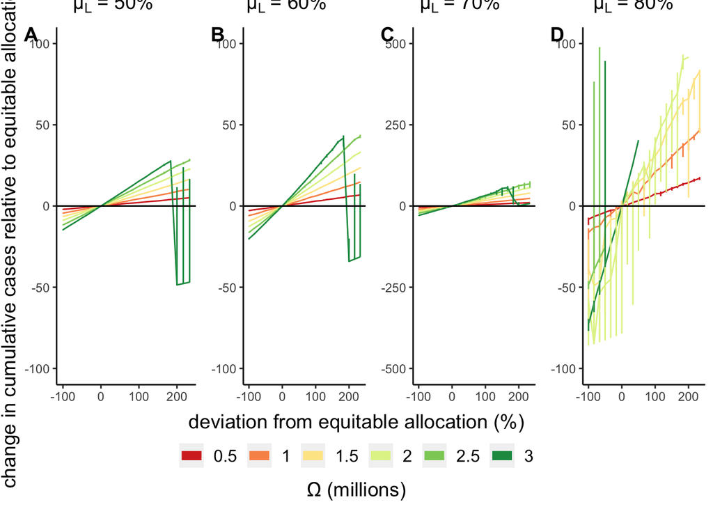

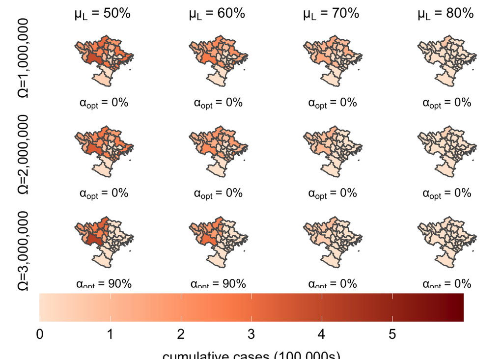

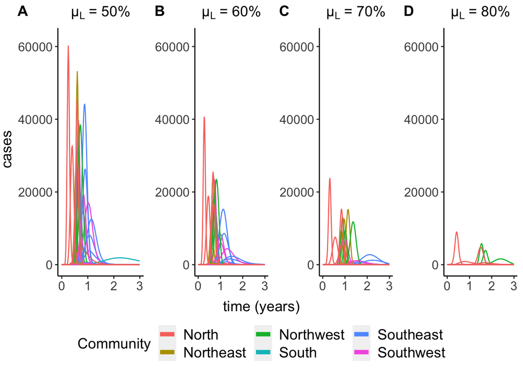

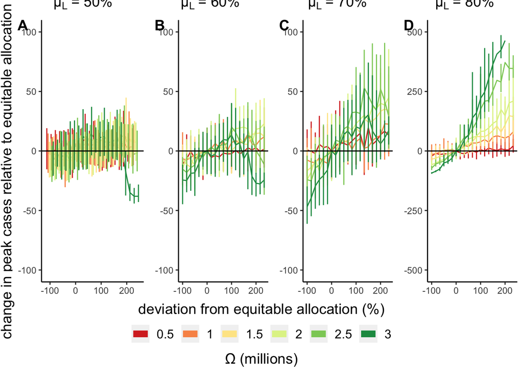

[figure not shown]

```r
seed_provinces <- c("Hà Giang")
for (i in seed_provinces) {
  print(i)
  sum_stats <- readRDS(file=paste0("sims_sum_stats/stochastic/", i))
  tot_inf_main_plot(sum_stats, i, stochastic=TRUE)
  geo_case_nums(sum_stats, i)
  typical_inf_dynamics(i)
  peak_inf_main_plot(sum_stats, i, stochastic=TRUE)
  peak_time_main_plot(sum_stats, i, stochastic=TRUE)
}
```

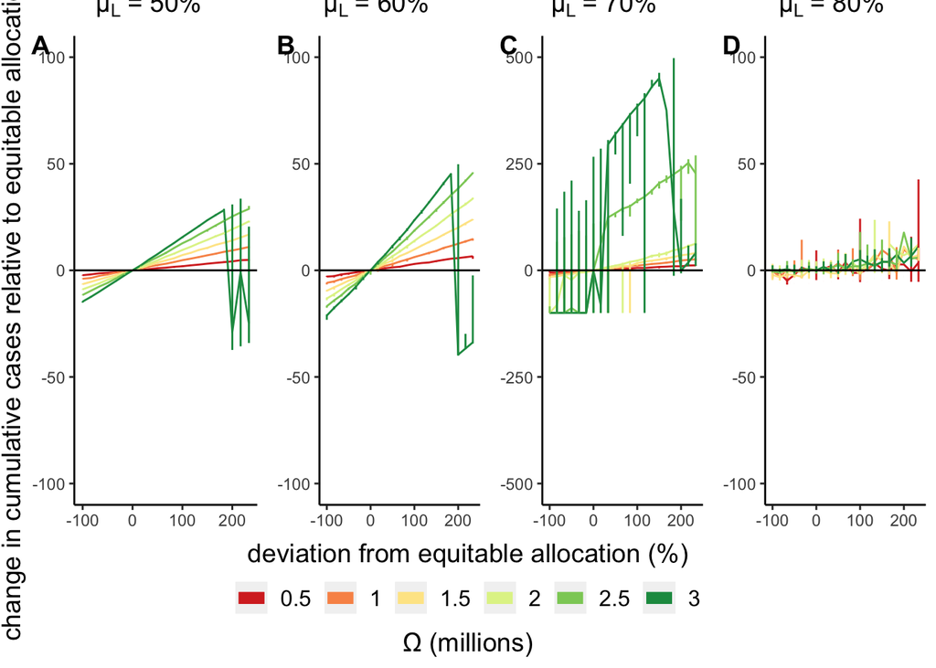

```r
seed_provinces <- c("Hà Nam")
for (i in seed_provinces) {
  sum_stats <- readRDS(file=paste0("sims_sum_stats/stochastic/", i))
  tot_inf_main_plot(sum_stats, i, stochastic=TRUE)
  #geo_case_nums(sum_stats, i)
  #typical_inf_dynamics(i)
  #peak_inf_main_plot(sum_stats, i, stochastic=TRUE)
  #peak_time_main_plot(sum_stats, i, stochastic=TRUE)
}
```